# Module 3

Neha Parulekar

February 8, 2016

## Additional packages needed

To run the code in M03_Lesson_02.Rmd you may need additional packages.

- If necessary install the following packages.
- `install.packages("ggplot2");`
- `install.packages("reshape2");`
- `install.packages("psych");`

```r
require(ggplot2)
require(reshape2)
require(psych)
```

## Assignment

- Download the compressed data from the U.S. [Bureau of Labor Statistics](https://en.wikipedia.org/wiki/Bureau_of_Labor_Statistics) http://www.bls.gov/ @ http://www.bls.gov/cew/data/files/2014/csv/2014_annual_singlefile.zip, and extract the .csv file.
- Run Principal Components Analysis on the BLS data and answer the following questions. (You can use any PCA function you wish, i.e. princomp(), prcomp(), principal() or by hand.)  
  **Reading the file**

```r
# set the working directory
setwd( "C:/Users/Neha/Desktop")
# loading the data
LaborStatistics <- read.csv("2014.annual.singlefile.csv")

# Checking the data
names(LaborStatistics)
```

```
##  [1] "area_fips"                        "own_code"
##  [3] "industry_code"                    "agglvl_code"
##  [5] "size_code"                        "year"
##  [7] "qtr"                              "disclosure_code"
##  [9] "annual_avg_estabs"                "annual_avg_emplvl"
## [11] "total_annual_wages"               "taxable_annual_wages"
## [13] "annual_contributions"             "annual_avg_wkly_wage"
## [15] "avg_annual_pay"                   "lq_disclosure_code"
## [17] "lq_annual_avg_estabs"             "lq_annual_avg_emplvl"
## [19] "lq_total_annual_wages"            "lq_taxable_annual_wages"
## [21] "lq_annual_contributions"          "lq_annual_avg_wkly_wage"
## [23] "lq_avg_annual_pay"                "oty_disclosure_code"
## [25] "oty_annual_avg_estabs_chg"        "oty_annual_avg_estabs_pct_chg"
## [27] "oty_annual_avg_emplvl_chg"        "oty_annual_avg_emplvl_pct_chg"
## [29] "oty_total_annual_wages_chg"       "oty_total_annual_wages_pct_chg"
## [31] "oty_taxable_annual_wages_chg"     "oty_taxable_annual_wages_pct_chg"
## [33] "oty_annual_contributions_chg"     "oty_annual_contributions_pct_chg"
## [35] "oty_annual_avg_wkly_wage_chg"     "oty_annual_avg_wkly_wage_pct_chg"
## [37] "oty_avg_annual_pay_chg"           "oty_avg_annual_pay_pct_chg"
```

```r
head(LaborStatistics)
```

```
##   area_fips own_code industry_code agglvl_code size_code year qtr
## 1     01000        0            10          50         0 2014   A
## 2     01000        1            10          51         0 2014   A
## 3     01000        1           102          52         0 2014   A
## 4     01000        1          1021          53         0 2014   A
## 5     01000        1          1022          53         0 2014   A
## 6     01000        1          1023          53         0 2014   A
##   disclosure_code annual_avg_estabs annual_avg_emplvl total_annual_wages
## 1                            117452           1863561        80668352987
## 2                              1186             53491         4148191291
## 3                              1186             53491         4148191291
## 4                               587             11462          719550831
## 5                                 2                13             430575
## 6                                17               147           11630538
##   taxable_annual_wages annual_contributions annual_avg_wkly_wage
```

[output cut: 83 more lines]

```r
# retriving the dimensions of the data
dim(LaborStatistics)
```

```
## [1] 3569127      38
```

```r
# Removing the first eight columns from the data
RemoveCols <- c("area_fips","industry_code","size_code","qtr","own_code","agglvl_code","year","disclosure_code","lq_disclosure_code","oty_disclosure_code")
LaborStatistics <- LaborStatistics[,!(names(LaborStatistics) %in% RemoveCols)]
head(LaborStatistics)
```

```
##   annual_avg_estabs annual_avg_emplvl total_annual_wages
## 1            117452           1863561        80668352987
## 2              1186             53491         4148191291
## 3              1186             53491         4148191291
## 4               587             11462          719550831
## 5                 2                13             430575
## 6                17               147           11630538
##   taxable_annual_wages annual_contributions annual_avg_wkly_wage
## 1          13917605638            316127565                  832
## 2                    0                    0                 1491
## 3                    0                    0                 1491
## 4                    0                    0                 1207
## 5                    0                    0                  649
## 6                    0                    0                 1527
##   avg_annual_pay lq_annual_avg_estabs lq_annual_avg_emplvl
```

[output cut: 69 more lines]

```r
# checking the dimensions of the data
dim(LaborStatistics)
```

```
## [1] 3569127      28
```

- Run Principal Components Analysis on the BLS data and answer the following questions. (You can use any PCA function you wish, i.e. princomp(), prcomp(), principal() or by hand.)

```r
LaborStatistic.fit.A <-  princomp(formula = ~., data = LaborStatistics, cor = TRUE, na.action=na.exclude)
print(LaborStatistic.fit.A)
```

```
## Call:
## princomp(formula = ~., data = LaborStatistics, na.action = na.exclude,
##     cor = TRUE)
##
## Standard deviations:
##       Comp.1       Comp.2       Comp.3       Comp.4       Comp.5
## 3.0871243914 1.9539344628 1.6826950969 1.5562368831 1.3363812066
##       Comp.6       Comp.7       Comp.8       Comp.9      Comp.10
## 1.1830067372 1.1629781715 1.0401246533 0.9855732862 0.9342121508
##      Comp.11      Comp.12      Comp.13      Comp.14      Comp.15
## 0.7988757665 0.6495354134 0.5003750633 0.4017578339 0.3875207081
##      Comp.16      Comp.17      Comp.18      Comp.19      Comp.20
## 0.3630700797 0.3044679826 0.1757438733 0.1341101339 0.1268132207
##      Comp.21      Comp.22      Comp.23      Comp.24      Comp.25
## 0.1142661371 0.0838781775 0.0480066349 0.0250238568 0.0023137519
##      Comp.26      Comp.27      Comp.28
## 0.0020174013 0.0009981984 0.0001649247
##
##  28  variables and  3569127 observations.
```

```r
LaborStatistic.fit.B <- prcomp(LaborStatistics,center = TRUE, scale.= TRUE)
print(LaborStatistic.fit.B)
```

```
## Standard deviations:
##  [1] 3.0871243914 1.9539344628 1.6826950969 1.5562368831 1.3363812067
##  [6] 1.1830067372 1.1629781715 1.0401246533 0.9855732862 0.9342121508
## [11] 0.7988757665 0.6495354134 0.5003750633 0.4017578338 0.3875207081
## [16] 0.3630700797 0.3044679826 0.1757438733 0.1341101339 0.1268132207
## [21] 0.1142661371 0.0838781775 0.0480066349 0.0250238568 0.0023137374
## [26] 0.0020173920 0.0009981366 0.0001649820
##
## Rotation:
##                                            PC1          PC2           PC3
## annual_avg_estabs                -3.214512e-01 -0.003968394  0.0002958097
## annual_avg_emplvl                -3.216322e-01 -0.003623199  0.0002439913
## total_annual_wages               -3.212306e-01 -0.002658919  0.0001402159
## taxable_annual_wages             -3.227689e-01 -0.003593422  0.0002449286
## annual_contributions             -3.221247e-01 -0.003450250  0.0002325100
## annual_avg_wkly_wage             -5.670267e-03  0.475632759 -0.0477659642
## avg_annual_pay                   -5.670266e-03  0.475632644 -0.0477666118
## lq_annual_avg_estabs              9.341359e-05 -0.001357601 -0.0017021837
## lq_annual_avg_emplvl             -1.125203e-04  0.044966798 -0.0150787970
## lq_total_annual_wages            -1.008715e-04  0.046108356 -0.0156771087
## lq_taxable_annual_wages          -2.281221e-04  0.055094515 -0.0165877803
## lq_annual_contributions          -1.884392e-04  0.051121959 -0.0155938425
## lq_annual_avg_wkly_wage          -4.986897e-03  0.447728628 -0.0513847497
## lq_avg_annual_pay                -4.987079e-03  0.447721690 -0.0513843307
## oty_annual_avg_estabs_chg        -3.034500e-01 -0.003540046  0.0003731319
## oty_annual_avg_estabs_pct_chg    -1.042062e-04 -0.005172681  0.0078162081
## oty_annual_avg_emplvl_chg        -3.207435e-01 -0.003957954  0.0003672195
## oty_annual_avg_emplvl_pct_chg    -6.695079e-04  0.042850508  0.0198981957
## oty_total_annual_wages_chg       -3.211440e-01 -0.001994470  0.0002231390
## oty_total_annual_wages_pct_chg   -1.149577e-04  0.047079725  0.5561446961
## oty_taxable_annual_wages_chg     -3.181631e-01 -0.003372105  0.0002870288
## oty_taxable_annual_wages_pct_chg -1.264161e-04  0.011460045  0.0027454450
## oty_annual_contributions_chg      2.874907e-01  0.003405565 -0.0001406501
## oty_annual_contributions_pct_chg -2.991355e-05  0.014282472  0.0048058034
## oty_annual_avg_wkly_wage_chg     -1.316688e-03  0.252276406  0.0180901780
## oty_annual_avg_wkly_wage_pct_chg -1.109418e-04  0.049874013  0.5825456693
## oty_avg_annual_pay_chg           -1.316475e-03  0.252275224  0.0180880730
## oty_avg_annual_pay_pct_chg       -1.137049e-04  0.050284103  0.5825482605
##                                            PC4           PC5           PC6
## annual_avg_estabs                -2.328513e-04  6.174991e-04 -0.0002549995
```

[output cut: 244 more lines]

```
## lq_avg_annual_pay                -7.924204e-03
## oty_annual_avg_estabs_chg        -1.188400e-06
## oty_annual_avg_estabs_pct_chg    -5.565740e-07
## oty_annual_avg_emplvl_chg        -1.779833e-06
## oty_annual_avg_emplvl_pct_chg     5.672069e-08
## oty_total_annual_wages_chg       -1.754741e-06
## oty_total_annual_wages_pct_chg    4.066131e-07
## oty_taxable_annual_wages_chg      3.219213e-07
## oty_taxable_annual_wages_pct_chg  4.021521e-08
## oty_annual_contributions_chg      5.998082e-07
## oty_annual_contributions_pct_chg -2.749563e-08
## oty_annual_avg_wkly_wage_chg      1.091497e-01
## oty_annual_avg_wkly_wage_pct_chg -2.938436e-04
## oty_avg_annual_pay_chg           -1.091500e-01
## oty_avg_annual_pay_pct_chg        2.938230e-04
```

```r
# getting the summary
summary(LaborStatistic.fit.A)
```

```
## Importance of components:
##                           Comp.1    Comp.2    Comp.3     Comp.4     Comp.5
## Standard deviation     3.0871244 1.9539345 1.6826951 1.55623688 1.33638121
## Proportion of Variance 0.3403692 0.1363521 0.1011237 0.08649547 0.06378267
## Cumulative Proportion  0.3403692 0.4767213 0.5778450 0.66434046 0.72812313
##                            Comp.6     Comp.7     Comp.8     Comp.9
## Standard deviation     1.18300674 1.16297817 1.04012465 0.98557329
## Proportion of Variance 0.04998232 0.04830422 0.03863783 0.03469124
## Cumulative Proportion  0.77810545 0.82640967 0.86504750 0.89973874
##                           Comp.10    Comp.11    Comp.12     Comp.13
## Standard deviation     0.93421215 0.79887577 0.64953541 0.500375063
## Proportion of Variance 0.03116973 0.02279295 0.01506772 0.008941972
## Cumulative Proportion  0.93090847 0.95370142 0.96876914 0.977711111
##                           Comp.14     Comp.15     Comp.16     Comp.17
## Standard deviation     0.40175783 0.387520708 0.363070080 0.304467983
## Proportion of Variance 0.00576462 0.005363296 0.004707853 0.003310741
## Cumulative Proportion  0.98347573 0.988839027 0.993546880 0.996857621
##                            Comp.18      Comp.19      Comp.20      Comp.21
## Standard deviation     0.175743873 0.1341101339 0.1268132207 0.1142661371
## Proportion of Variance 0.001103068 0.0006423403 0.0005743426 0.0004663125
## Cumulative Proportion  0.997960689 0.9986030297 0.9991773723 0.9996436848
##                             Comp.22      Comp.23      Comp.24      Comp.25
## Standard deviation     0.0838781775 4.800663e-02 2.502386e-02 2.313752e-03
## Proportion of Variance 0.0002512696 8.230846e-05 2.236405e-05 1.911946e-07
## Cumulative Proportion  0.9998949544 9.999773e-01 9.999996e-01 9.999998e-01
##                             Comp.26      Comp.27      Comp.28
## Standard deviation     2.017401e-03 9.981984e-04 1.649247e-04
## Proportion of Variance 1.453539e-07 3.558571e-08 9.714336e-10
## Cumulative Proportion  1.000000e+00 1.000000e+00 1.000000e+00
```

```r
names(LaborStatistic.fit.A)
```

```
## [1] "sdev"     "loadings" "center"   "scale"    "n.obs"    "scores"
## [7] "call"
```

```r
summary(LaborStatistic.fit.B)
```

```
## Importance of components:
##                           PC1    PC2    PC3    PC4     PC5     PC6    PC7
## Standard deviation     3.0871 1.9539 1.6827 1.5562 1.33638 1.18301 1.1630
## Proportion of Variance 0.3404 0.1363 0.1011 0.0865 0.06378 0.04998 0.0483
## Cumulative Proportion  0.3404 0.4767 0.5778 0.6643 0.72812 0.77811 0.8264
##                            PC8     PC9    PC10    PC11    PC12    PC13
## Standard deviation     1.04012 0.98557 0.93421 0.79888 0.64954 0.50038
## Proportion of Variance 0.03864 0.03469 0.03117 0.02279 0.01507 0.00894
## Cumulative Proportion  0.86505 0.89974 0.93091 0.95370 0.96877 0.97771
##                           PC14    PC15    PC16    PC17   PC18    PC19
## Standard deviation     0.40176 0.38752 0.36307 0.30447 0.1757 0.13411
## Proportion of Variance 0.00576 0.00536 0.00471 0.00331 0.0011 0.00064
## Cumulative Proportion  0.98348 0.98884 0.99355 0.99686 0.9980 0.99860
##                           PC20    PC21    PC22    PC23    PC24     PC25
## Standard deviation     0.12681 0.11427 0.08388 0.04801 0.02502 0.002314
## Proportion of Variance 0.00057 0.00047 0.00025 0.00008 0.00002 0.000000
## Cumulative Proportion  0.99918 0.99964 0.99989 0.99998 1.00000 1.000000
##                            PC26      PC27     PC28
## Standard deviation     0.002017 0.0009981 0.000165
## Proportion of Variance 0.000000 0.0000000 0.000000
## Cumulative Proportion  1.000000 1.0000000 1.000000
```

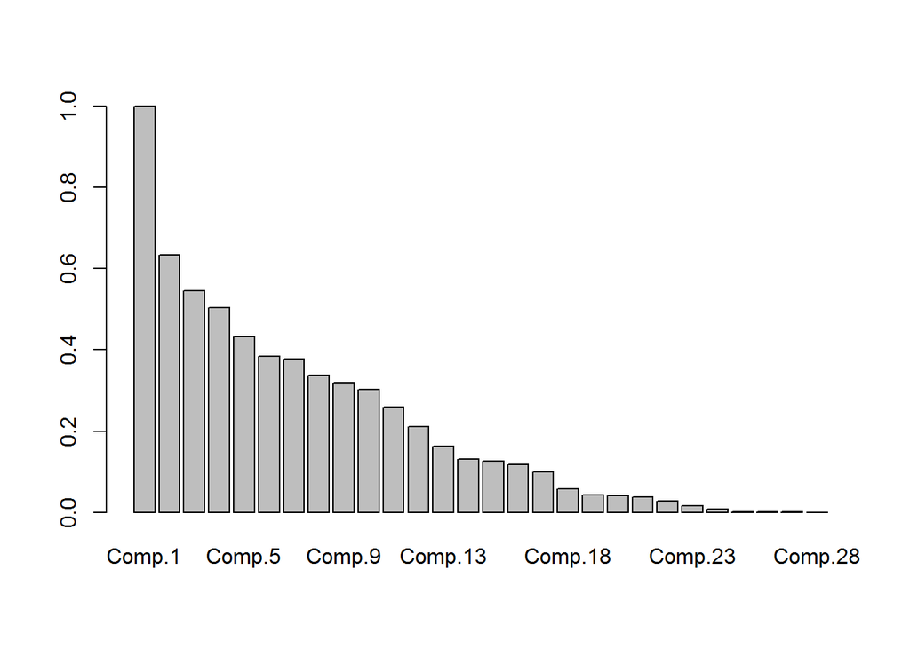

```r
#plotting the screeplot, barplot, biplot
#screeplot(LaborStatistic.fit.A)
barplot(LaborStatistic.fit.A$sdev/LaborStatistic.fit.A$sdev[1])
```

```r
#biplot(LaborStatistic.fit.A, expand=100, xlim=c(-0.1, 0.1), ylim=c(-0.1, 0.1))

#loadint the required package and plotting ggbiplot

library(devtools)
install_github("vqv/ggbiplot")
```

```
## Skipping install for github remote, the SHA1 (7325e880) has not changed since last install.
##   Use `force = TRUE` to force installation
```

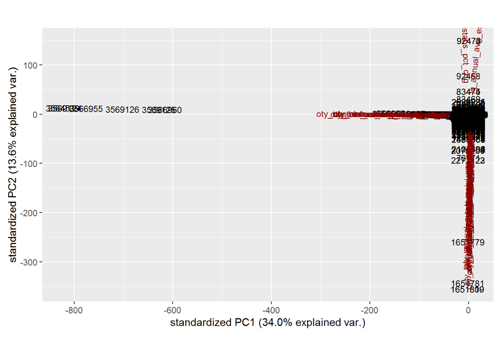

```r
library(ggbiplot)
fit<- princomp(LaborStatistics, cor=TRUE)
ggbiplot(fit, labels = rownames(LaborStatistics))
```

## **Answers**

**(a) What proportion of the total variation in the data is explained by each of the principal components?**

PC1 PC2 PC3 PC4 PC5 PC6 PC7 0.3404 0.1363 0.1011 0.0865 0.06378 0.04998 0.0483

PC8 PC9 PC10 PC11 PC12 PC13 0.03864 0.03469 0.03117 0.02279 0.01507 0.00894

PC14 PC15 PC16 PC17 PC18 PC19 0.00576 0.00536 0.00471 0.00331 0.0011 0.00064

PC20 PC21 PC22 PC23 PC24 PC25 0.00057 0.00047 0.00025 0.00008 0.00002 0.000000

PC26 PC27 PC28 0.000000 0.0000000 0.000000

**(b) Plot a screeplot.**

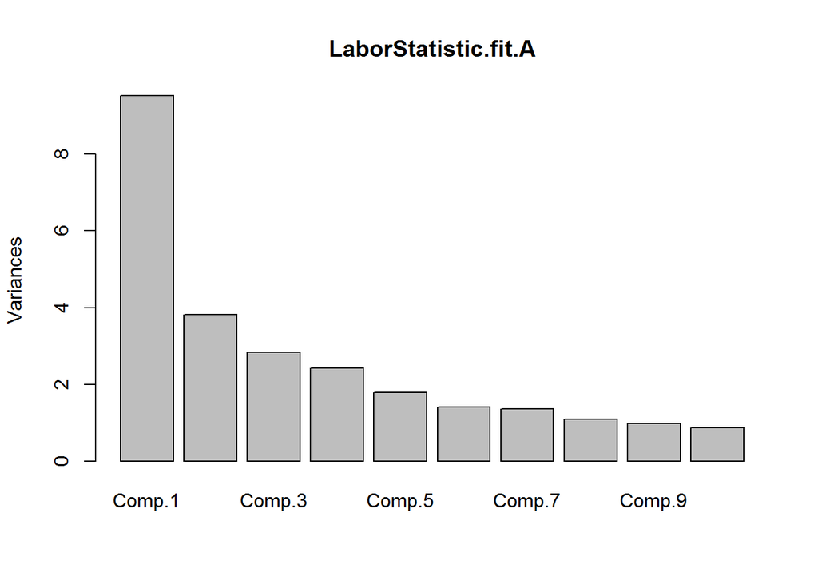

```r
screeplot(LaborStatistic.fit.A)
```

**(c) Based on the variation explained for each of these components, which, if any, components would you use?** As we can see more than 90% of variance of the data was captured by first 10 PCs. So it would be sufficient to use those components.

**(d) Is there evidence of clustering in the data by creating biplots of the each of the components plotted against one another?** *It takes too long to run.* But running the **ggbiplot** we can see that there is clustering in data.

**(e) Do any of the biplots reveal any interesting structure?** *The biplot takes too long to run* Ruuning **ggbiplot** we can see the points in the labor statistics data would fall when we project from 28 space to 2 space.They are not evenly scattered about the projections.